# RD modelling - simulations

Doranne Thomassen

3/22/2021

# Single trial

## Binary treatment variable only

### Sample size 500 per arm

```r
set.seed(196)
n_arm <- 500
treat <- c(rep(0,n_arm), rep(1,n_arm))
cat("", file = "modelstats.html", append = FALSE)

beta_xlim = c(-0.3,0.7)
beta_ylim = c(0,40)
#beta fixed, increase alpha

#alpha = 0.5
true.beta <- 0.3
true.p <- 0.5+true.beta*treat

cure <- rbinom(n=length(treat), size=1, prob = true.p)
trial.dat <- data.frame(cure, treat)
print(table(trial.dat$cure, trial.dat$treat))
```

```
##
##       0   1
##   0 239 101
##   1 261 399
```

```r
plots <- run.sim(true.beta=true.beta,
        trial.dat = trial.dat,
        filename="1x_bin_p=0.5+0.3x",
        title="x_{i1} binary, p_{i}=0.5+0.3x_{i1}",
        true.p = true.p,
        beta_xlim = beta_xlim,
        beta_ylim = beta_ylim)

beta.plot <- plots$beta.frame
xicpt.plot <- plots$xicpt
plots$kable_modstats
```

1. Proposed model
3. Logistic model + transform
2. Model by Warn et al.

MLE binomial GLM id-link

MLE binomial GLM logit-link

OLS estimate

Brier.mean

0.2054

0.2054

0.2054

0.2054

0.2054

0.2054

Brier.median

0.2054

0.2054

0.2054

0.2054

0.2054

0.2054

RMSE.p.mean

0.0156

0.0162

0.0159

0.0156

0.0156

0.0156

RMSE.p.median

0.0156

0.0159

0.0162

0.0156

0.0156

0.0156

MAE.p.mean

0.0125

0.0127

0.0127

0.0120

0.0120

0.0120

MAE.p.median

0.0124

0.0127

0.0128

0.0120

0.0120

0.0120

L1_loss.mean

0.0251

0.0254

0.0253

0.0240

0.0240

0.0240

L1_loss.median

0.0253

0.0250

0.0258

0.0240

0.0240

0.0240

IC

1199.4287

1199.6648

1199.3530

1199.3414

1199.3414

NA

Rhat_Conv

1.0022

1.0005

1.0023

-1.0000

-1.0000

-1.0000

RunTimes

11.0243

14.8883

10.1227

0.0048

0.0026

0.0012

ESS

900.0000

2000.0000

2000.0000

0.0000

0.0000

0.0000

ESSp0

350.0000

1500.0000

800.0000

0.0000

0.0000

0.0000

ESSp1

2000.0000

750.0000

1600.0000

0.0000

0.0000

0.0000

```r
rm(cure, trial.dat, true.beta, true.p)

#alpha = 0.6
true.beta <- 0.3
true.p <- 0.6+true.beta*treat

cure <- rbinom(n=length(treat), size=1, prob = true.p)
trial.dat <- data.frame(cure, treat)
print(table(trial.dat$cure, trial.dat$treat))
```

```
##
##       0   1
##   0 204  57
##   1 296 443
```

```r
plots <- run.sim(true.beta=true.beta,
        trial.dat = trial.dat,
        filename="1x_bin_p=0.6+0.3x",
        title="x_{i1} binary, p_{i}=0.6+0.3x_{i1}",
        true.p = true.p,
        beta_xlim = beta_xlim,
        beta_ylim = beta_ylim)

beta.plot <- rbind(beta.plot, plots$beta.frame)
xicpt.plot <- rbind(xicpt.plot, plots$xicpt)
plots$kable_modstats
```

1. Proposed model
3. Logistic model + transform
2. Model by Warn et al.

MLE binomial GLM id-link

MLE binomial GLM logit-link

OLS estimate

Brier.mean

0.1713

0.1713

0.1713

0.1713

0.1713

0.1713

Brier.median

0.1713

0.1713

0.1713

0.1713

0.1713

0.1713

RMSE.p.mean

0.0124

0.0114

0.0124

0.0114

0.0114

0.0114

RMSE.p.median

0.0119

0.0112

0.0122

0.0114

0.0114

0.0114

MAE.p.mean

0.0117

0.0109

0.0120

0.0110

0.0110

0.0110

MAE.p.median

0.0114

0.0107

0.0119

0.0110

0.0110

0.0110

L1_loss.mean

0.0082

0.0063

0.0058

0.0060

0.0060

0.0060

L1_loss.median

0.0091

0.0065

0.0053

0.0060

0.0060

0.0060

IC

1034.9412

1035.3141

1034.7678

1034.9198

1034.9198

NA

Rhat_Conv

1.0011

1.0008

1.0013

-1.0000

-1.0000

-1.0000

RunTimes

9.8932

14.6817

9.6458

0.0018

0.0019

0.0007

ESS

2000.0000

2000.0000

2000.0000

0.0000

0.0000

0.0000

ESSp0

510.0000

1700.0000

770.0000

0.0000

0.0000

0.0000

ESSp1

1000.0000

2000.0000

2000.0000

0.0000

0.0000

0.0000

```r
rm(cure, trial.dat, true.beta, true.p)

# alpha =0.69
true.beta <- 0.3
true.p <- 0.69+true.beta*treat

cure <- rbinom(n=length(treat), size=1, prob = true.p)
trial.dat <- data.frame(cure, treat)
print(table(trial.dat$cure, trial.dat$treat))
```

```
##
##       0   1
##   0 157   9
##   1 343 491
```

```r
plots <- run.sim(true.beta=true.beta,
        trial.dat = trial.dat,
        filename="1x_bin_p=0.69+0.3x",
        title="x_{i1} binary, p_{i}=0.69+0.3x_{i1}",
        true.p = true.p,
        beta_xlim = beta_xlim,
        beta_ylim = beta_ylim)

beta.plot <- rbind(beta.plot, plots$beta.frame)
xicpt.plot <- rbind(xicpt.plot, plots$xicpt)
plots$kable_modstats
```

1. Proposed model
3. Logistic model + transform
2. Model by Warn et al.

MLE binomial GLM id-link

MLE binomial GLM logit-link

OLS estimate

Brier.mean

0.1165

0.1165

0.1165

0.1165

0.1165

0.1165

Brier.median

0.1165

0.1165

0.1165

0.1165

0.1165

0.1165

RMSE.p.mean

0.0076

0.0063

0.0079

0.0063

0.0063

0.0063

RMSE.p.median

0.0070

0.0058

0.0074

0.0063

0.0063

0.0063

MAE.p.mean

0.0070

0.0058

0.0076

0.0060

0.0060

0.0060

MAE.p.median

0.0062

0.0054

0.0071

0.0060

0.0060

0.0060

L1_loss.mean

0.0060

0.0052

0.0045

0.0040

0.0040

0.0040

L1_loss.median

0.0066

0.0054

0.0045

0.0040

0.0040

0.0040

IC

716.6834

719.4909

716.3752

716.4138

716.4138

NA

Rhat_Conv

1.0239

1.0017

1.0013

-1.0000

-1.0000

-1.0000

RunTimes

9.5885

14.6764

10.0612

0.0015

0.0022

0.0007

ESS

68.0000

1300.0000

2000.0000

0.0000

0.0000

0.0000

ESSp0

75.0000

970.0000

1700.0000

0.0000

0.0000

0.0000

ESSp1

760.0000

2000.0000

2000.0000

0.0000

0.0000

0.0000

```r
rm(cure, trial.dat, true.beta, true.p)


###
#alpha = 0.8
true.beta <- 0
true.p <- 0.8+true.beta*treat

cure <- rbinom(n=length(treat), size=1, prob = true.p)
trial.dat <- data.frame(cure, treat)
print(table(trial.dat$cure, trial.dat$treat))
```

```
##
##       0   1
##   0 107  91
##   1 393 409
```

```r
plots <- run.sim(true.beta=true.beta,
        trial.dat = trial.dat,
        filename="1x_bin_p=0.8+0x",
        title="x_{i1} binary, p_{i}=0.8+0*x_{i1}",
        true.p = true.p,
        beta_xlim = beta_xlim,
        beta_ylim = beta_ylim)

beta.plot <- rbind(beta.plot, plots$beta.frame)
xicpt.plot <- rbind(xicpt.plot, plots$xicpt)
plots$kable_modstats
```

1. Proposed model
3. Logistic model + transform
2. Model by Warn et al.

MLE binomial GLM id-link

MLE binomial GLM logit-link

OLS estimate

Brier.mean

0.1585

0.1585

0.1585

0.1585

0.1585

0.1585

Brier.median

0.1585

0.1585

0.1585

0.1585

0.1585

0.1585

RMSE.p.mean

0.0158

0.0156

0.0159

0.0161

0.0161

0.0161

RMSE.p.median

0.0157

0.0156

0.0160

0.0161

0.0161

0.0161

MAE.p.mean

0.0158

0.0155

0.0159

0.0160

0.0160

0.0160

MAE.p.median

0.0156

0.0154

0.0160

0.0160

0.0160

0.0160

L1_loss.mean

0.0315

0.0311

0.0317

0.0320

0.0320

0.0320

L1_loss.median

0.0306

0.0312

0.0315

0.0320

0.0320

0.0320

IC

997.8046

998.0014

997.5542

997.6210

997.6210

NA

Rhat_Conv

1.0006

1.0019

1.0005

-1.0000

-1.0000

-1.0000

RunTimes

9.6099

14.7127

17.3256

0.0018

0.0019

0.0007

ESS

2000.0000

1100.0000

2000.0000

0.0000

0.0000

0.0000

ESSp0

2000.0000

2000.0000

1000.0000

0.0000

0.0000

0.0000

ESSp1

2000.0000

1400.0000

970.0000

0.0000

0.0000

0.0000

```r
rm(cure, trial.dat, true.beta, true.p)

#alpha = 0.9
true.beta <- 0
true.p <- 0.9+true.beta*treat

cure <- rbinom(n=length(treat), size=1, prob = true.p)
trial.dat <- data.frame(cure, treat)
print(table(trial.dat$cure, trial.dat$treat))
```

```
##
##       0   1
##   0  49  47
##   1 451 453
```

```r
plots <- run.sim(true.beta=true.beta,
        trial.dat = trial.dat,
        filename="1x_bin_p=0.9+0x",
        title="x_{i1} binary, p_{i}=0.9+0*x_{i1}",
        true.p = true.p,
        beta_xlim = beta_xlim,
        beta_ylim = beta_ylim)

beta.plot <- rbind(beta.plot, plots$beta.frame)
xicpt.plot <- rbind(xicpt.plot, plots$xicpt)
plots$kable_modstats
```

1. Proposed model
3. Logistic model + transform
2. Model by Warn et al.

MLE binomial GLM id-link

MLE binomial GLM logit-link

OLS estimate

Brier.mean

0.0868

0.0868

0.0868

0.0868

0.0868

0.0868

Brier.median

0.0868

0.0868

0.0868

0.0868

0.0868

0.0868

RMSE.p.mean

0.0031

0.0048

0.0028

0.0045

0.0045

0.0045

RMSE.p.median

0.0038

0.0055

0.0031

0.0045

0.0045

0.0045

MAE.p.mean

0.0022

0.0043

0.0026

0.0040

0.0040

0.0040

MAE.p.median

0.0028

0.0051

0.0030

0.0040

0.0040

0.0040

L1_loss.mean

0.0044

0.0044

0.0022

0.0040

0.0040

0.0040

L1_loss.median

0.0046

0.0044

0.0020

0.0040

0.0040

0.0040

IC

636.4826

639.1771

636.4786

636.3621

636.3621

NA

Rhat_Conv

1.0031

1.0025

1.0005

-1.0000

-1.0000

-1.0000

RunTimes

10.1586

14.5707

9.7201

0.0015

0.0020

0.0006

ESS

580.0000

750.0000

2000.0000

0.0000

0.0000

0.0000

ESSp0

1500.0000

1100.0000

2000.0000

0.0000

0.0000

0.0000

ESSp1

920.0000

2000.0000

2000.0000

0.0000

0.0000

0.0000

```r
rm(cure, trial.dat, true.beta, true.p)


# alpha = 0.99
true.beta <- 0
true.p <- 0.99 + true.beta*treat

cure <- rbinom(n=length(treat), size=1, prob = true.p)
trial.dat <- data.frame(cure, treat)
print(table(trial.dat$cure, trial.dat$treat))
```

```
##
##       0   1
##   0   6   6
##   1 494 494
```

```r
plots <- run.sim(true.beta=true.beta,
        trial.dat = trial.dat,
        filename="1x_bin_p=0.99+0x",
        title="x_{i1} binary, p_{i}=0.99+0*x_{i1}",
        true.p = true.p,
        beta_xlim = beta_xlim,
        beta_ylim = beta_ylim)

beta.plot <- rbind(beta.plot, plots$beta.frame)
xicpt.plot <- rbind(xicpt.plot, plots$xicpt)
plots$kable_modstats
```

1. Proposed model
3. Logistic model + transform
2. Model by Warn et al.

MLE binomial GLM id-link

MLE binomial GLM logit-link

OLS estimate

Brier.mean

0.0119

0.0119

0.0119

0.0119

0.0119

0.0119

Brier.median

0.0119

0.0119

0.0119

0.0119

0.0119

0.0119

RMSE.p.mean

0.0040

0.0020

0.0040

0.0020

0.0020

0.0020

RMSE.p.median

0.0034

0.0013

0.0033

0.0020

0.0020

0.0020

MAE.p.mean

0.0040

0.0020

0.0039

0.0020

0.0020

0.0020

MAE.p.median

0.0034

0.0013

0.0033

0.0020

0.0020

0.0020

L1_loss.mean

0.0002

0.0002

0.0005

0.0000

0.0000

0.0000

L1_loss.median

0.0001

0.0002

0.0005

0.0000

0.0000

0.0000

IC

134.2014

152.1623

134.1420

134.0038

134.0038

NA

Rhat_Conv

1.0005

1.0008

1.0006

-1.0000

-1.0000

-1.0000

RunTimes

9.5326

14.7422

9.5235

0.0020

0.0030

0.0013

ESS

2000.0000

2000.0000

2000.0000

0.0000

0.0000

0.0000

ESSp0

2000.0000

2000.0000

2000.0000

0.0000

0.0000

0.0000

ESSp1

2000.0000

2000.0000

2000.0000

0.0000

0.0000

0.0000

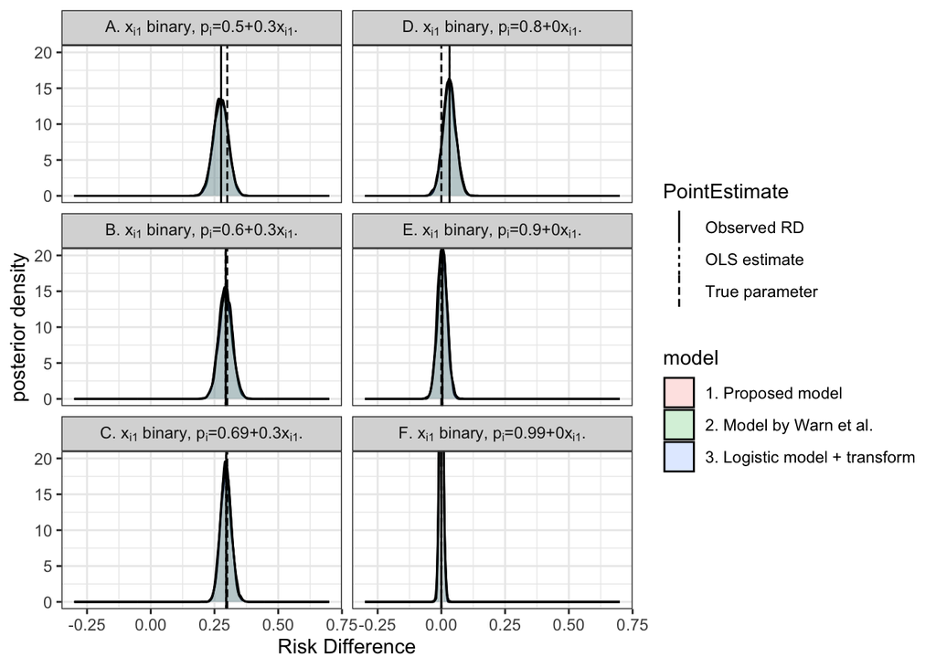

```r
rm(cure, trial.dat, true.beta, true.p)

###Plots

beta.plot$Scenario <- factor(beta.plot$Scenario,
                   levels=c("1x_bin_p=0.5+0.3x",
                            "1x_bin_p=0.6+0.3x",
                            "1x_bin_p=0.69+0.3x",
                            "1x_bin_p=0.8+0x",
                            "1x_bin_p=0.9+0x",
                            "1x_bin_p=0.99+0x"),
                   labels=c(expression(paste("A. ", x[i*1], " binary, ", p[i],"=0.5+0.3",x[i*1],".")),
                            expression(paste("B. ", x[i*1], " binary, ", p[i],"=0.6+0.3",x[i*1],".")),
                            expression(paste("C. ", x[i*1], " binary, ", p[i],"=0.69+0.3",x[i*1],".")),
                            expression(paste("D. ", x[i*1], " binary, ", p[i],"=0.8+0",x[i*1],".")),
                            expression(paste("E. ", x[i*1], " binary, ", p[i],"=0.9+0",x[i*1],".")),
                            expression(paste("F. ", x[i*1], " binary, ", p[i],"=0.99+0",x[i*1],"."))
                            ))

xicpt.plot$Scenario <- factor(xicpt.plot$Scenario,
                   levels=c("1x_bin_p=0.5+0.3x",
                            "1x_bin_p=0.6+0.3x",
                            "1x_bin_p=0.69+0.3x",
                            "1x_bin_p=0.8+0x",
                            "1x_bin_p=0.9+0x",
                            "1x_bin_p=0.99+0x"),
                   labels=c(expression(paste("A. ", x[i*1], " binary, ", p[i],"=0.5+0.3",x[i*1],".")),
                            expression(paste("B. ", x[i*1], " binary, ", p[i],"=0.6+0.3",x[i*1],".")),
                            expression(paste("C. ", x[i*1], " binary, ", p[i],"=0.69+0.3",x[i*1],".")),
                            expression(paste("D. ", x[i*1], " binary, ", p[i],"=0.8+0",x[i*1],".")),
                            expression(paste("E. ", x[i*1], " binary, ", p[i],"=0.9+0",x[i*1],".")),
                            expression(paste("F. ", x[i*1], " binary, ", p[i],"=0.99+0",x[i*1],"."))
                            ))

##plot maken
    print(
    plot1 <- ggplot(beta.plot, aes(beta, fill = model)) +
    geom_density(alpha = 0.2) +
    geom_vline(data=xicpt.plot, aes(xintercept = xicpts, linetype=PointEstimate)) +
    ylab("posterior density")+
    xlab(expression("Risk Difference"))+
    xlim(beta_xlim)+
    ylim(beta_ylim)+
    theme_bw()+
    coord_cartesian(ylim=c(0,20))+
    facet_wrap(~Scenario, ncol = 2, dir = "v", labeller = label_parsed))
```

```r
ggsave(plot = plot1, filename="1x_bin.pdf", height=6, width = 7.5)
```